# ErythroCite database

# Data for manuscript

```r
df_years <- refs %>%
  as.data.frame() %>%
  select(year) %>%
  mutate(year = as.numeric(as.character(year))) %>%
  filter(!is.na(year)) %>%
  group_by(year) %>%
  summarise(num_studies = n()) %>%
  arrange(year) %>%
  mutate(cumulative_studies = cumsum(num_studies))
```

## Range de years included in the database

```r
df_years %>%
  reframe(min_year = min(year),
          max_year = max(year),
          total_years = max_year - min_year)
```

```
## # A tibble: 1 × 3
##   min_year max_year total_years
##      <dbl>    <dbl>       <dbl>
## 1     1875     2024         149
```

## Extracting and counting journals

```r
journals <- refs %>%
  as.data.frame() %>%
  select(journal) %>%
  filter(!is.na(journal)) %>%
  group_by(journal) %>%
  summarise(num_articles = n()) %>%
  arrange(desc(num_articles))
```

## Journals with highest number of articles

```r
journals %>%
  slice_head(n = 15)
```

```
## # A tibble: 15 × 2
##    journal                                      num_articles
##    <chr>                                               <int>
##  1 Journal of Fish Biology                                14
##  2 Fish Physiology and Biochemistry                        9
##  3 Aquaculture                                             4
##  4 Aquaculture Research                                    4
##  5 Tissue and Cell                                         4
##  6 Aquaculture International                               3
##  7 Ecotoxicology and Environmental Safety                  3
##  8 Environmental Science and Pollution Research            3
##  9 Experimental medicine and surgery                       3
## 10 Fish and Shellfish Immunology                           3
## 11 Iranian Journal of Fisheries Sciences                   3
## 12 Journal of Applied Ichthyology                          3
## 13 Russian Journal of Marine Biology                       3
## 14 Aquatic Toxicology                                      2
## 15 Brazilian Journal of Biology                            2
```

## Calculate stats for both hemispheres (southern and northern)

```r
dat %>%
  filter(between(long_dec, -180, 180), between(lat_dec, -90, 90)) %>% # Include coordinates within expected ranges
  mutate(hemisphere = ifelse(lat_dec > 0, "Northern","Southern")) %>%
  group_by(hemisphere) %>%
  reframe(
    unique_studies   = n_distinct(key),
    unique_positions = n_distinct(unique(paste(lat_dec, long_dec, sep = "_"))), #count unique positions in the db, because some studies have more than one position
    unique_species   = n_distinct(species_reported),
    records          = n())
```

```
## # A tibble: 2 × 5
##   hemisphere unique_studies unique_positions unique_species records
##   <chr>               <int>            <int>          <int>   <int>
## 1 Northern              112              131            259    1119
## 2 Southern               21               23             34     120
```

## Number of species

```r
n_spp <- dat %>%
  distinct(species) %>%
  nrow()
n_spp
```

```
## [1] 660
```

## Number of species by lineage

```r
dat %>%
  group_by(class) %>%
  reframe(n_spp = length(unique(species)), total_study = length(unique(key)),
                 perc_species = (n_spp/660)* 100)
```

```
## # A tibble: 4 × 4
##   class          n_spp total_study perc_species
##   <chr>          <int>       <int>        <dbl>
## 1 Actinopterygii   595         180       90.2
## 2 Chondrichthyes    57          15        8.64
## 3 Cyclostomata       5           4        0.758
## 4 Dipnoi             3           3        0.455
```

## Counting studies by species

```r
dat %>%
  group_by(species) %>%
  summarise(num_studies = n_distinct(key)) %>%
  arrange(desc(num_studies)) %>%
  slice_head(n = 15)  # Limit to top 15 species based on the number of studies
```

```
## # A tibble: 15 × 2
##    species                 num_studies
##    <chr>                         <int>
##  1 Oncorhynchus mykiss              17
##  2 Cyprinus carpio                  12
##  3 Labeo rohita                     10
##  4 Oreochromis niloticus             8
##  5 Ctenopharyngodon idella           7
##  6 Carassius auratus                 6
##  7 Channa punctata                   6
##  8 Clarias gariepinus                6
##  9 Salmo trutta                      6
## 10 Clarias batrachus                 5
## 11 Lophius piscatorius               5
## 12 Salmo salar                       5
## 13 Tinca tinca                       5
## 14 Dicentrarchus labrax              4
## 15 Echeneis naucrates                4
```

## Counting records by species

```r
dat %>%
  group_by(species) %>%
  summarise(num_records = n()) %>%
  arrange(desc(num_records)) %>%
  slice_head(n = 15)  # Limit to top 15 species based on the number of records
```

```
## # A tibble: 15 × 2
##    species                     num_records
##    <chr>                             <int>
##  1 Ctenopharyngodon idella              82
##  2 Oreochromis niloticus                71
##  3 Hypophthalmichthys molitrix          63
##  4 Labeo rohita                         29
##  5 Oncorhynchus mykiss                  24
##  6 Cyprinus carpio                      18
##  7 Dicentrarchus labrax                 17
##  8 Channa punctata                      15
##  9 Salmo salar                          13
## 10 Clarias batrachus                    12
## 11 Abudefduf saxatilis                  11
## 12 Haemulon aurolineatum                11
## 13 Haemulon flavolineatum               11
## 14 Holocentrus ascensionis              11
## 15 Lutjanus griseus                     11
```

## Number of distinct species and studies by sex

```r
dat %>%
  group_by(sex) %>%
  reframe(n_spp = length(unique(species)),
          total_studies = length(unique(key))) %>%
  arrange(desc(total_studies))
```

```
## # A tibble: 4 × 3
##   sex    n_spp total_studies
##   <fct>  <int>         <int>
## 1 <NA>     623           155
## 2 female    31            20
## 3 male      30            18
## 4 both      29            12
```

## Number of distinct species and studies by life stage

```r
dat %>%
  group_by(life_stage) %>%
  reframe(n_spp = length(unique(species)),
          total_studies = length(unique(key))) %>%
  arrange(desc(total_studies))
```

```
## # A tibble: 4 × 3
##   life_stage  n_spp total_studies
##   <fct>       <int>         <int>
## 1 <NA>          611           104
## 2 adult          61            49
## 3 juvenile       30            32
## 4 fingerlings     3             4
```

## Number of distinct species and studies by realm

```r
dat %>%
  group_by(realm) %>%
  reframe(n_spp = length(unique(species)),
          total_studies = length(unique(key))) %>%
  arrange(desc(total_studies))
```

```
## # A tibble: 5 × 3
##   realm                      n_spp total_studies
##   <chr>                      <int>         <int>
## 1 freshwater-brackish           54            71
## 2 freshwater                    93            62
## 3 freshwater-brackish-marine    73            60
## 4 marine                       307            29
## 5 marine-brackish              133            24
```

## Helper function to summarise a variable

The following function allows for the extraction of descriptive information about which species present the highest and lowest values for each trait.

```r
get_summary <- function(var_name) {
  dat %>%
    group_by(species) %>%
    summarise(
      min_val = min(!!sym(var_name), na.rm = TRUE),
      max_val = max(!!sym(var_name), na.rm = TRUE)
    ) %>%
    summarise(
      min_species = species[which.min(min_val)],
      min_value = min(min_val, na.rm = TRUE),
      max_species = species[which.max(max_val)],
      max_value = max(max_val, na.rm = TRUE),
      range = max_value - min_value,
      magnitude_order = max_value / min_value
    ) %>%
    mutate(variable = var_name) %>%
    select(variable, min_species, min_value, max_species, max_value, range, magnitude_order)
}
```

## List of variables to analyze

```r
variables <- c("cell_area", "nucleus_area", "cell_volume", "nucleus_volume", "mcv")
```

## Generate the summary table

```r
summary_table <- bind_rows(lapply(variables, get_summary))
summary_table
```

```
## # A tibble: 5 × 7
##   variable    min_species min_value max_species max_value  range magnitude_order
##   <chr>       <chr>           <dbl> <chr>           <dbl>  <dbl>           <dbl>
## 1 cell_area   Iranocichl…     16.2  Protopteru…      945.   928.            58.2
## 2 nucleus_ar… Iranocichl…      2.56 Proscymnod…      157.   155.            61.5
## 3 cell_volume Iranocichl…     41.1  Protopteru…    17024. 16983.           414.
## 4 nucleus_vo… Iranocichl…      3.42 Protopteru…      710.   706.           207.
## 5 mcv         Solea sene…     14.4  Protopteru…     6940   6926.           482.
```

# Additional figures not included in the manuscript

## Figure only Actinopterygii

```r
summary_data_act <- dat %>%
  filter(class == "Actinopterygii") %>%
  group_by(species_underscored) %>%
  summarise(across(c(cell_area, cell_volume, nucleus_area, nucleus_volume, mcv),
                   ~ mean(., na.rm = TRUE)),
            .groups = "drop") %>%
  rename(
    "Cell area" = cell_area,
    "Cell volume" = cell_volume,
    "Nucleus area" = nucleus_area,
    "Nucleus volume" = nucleus_volume,
    "MCV" = mcv
  )

summary_data_act <- summary_data_act %>%
  mutate(across(c("Cell area", "Cell volume", "Nucleus area", "Nucleus volume", "MCV"),
                ~ (.-min(., na.rm = TRUE)) / (max(., na.rm = TRUE) - min(., na.rm = TRUE))))  # scale min-max by variable
summary_data_act
```

```
## # A tibble: 595 × 6
##    species_underscored `Cell area` `Cell volume` `Nucleus area` `Nucleus volume`
##    <chr>                     <dbl>         <dbl>          <dbl>            <dbl>
##  1 Abalistes_stellatus      0.0722      NaN              0.116          NaN
##  2 Abramis_brama            0.112         0.104        NaN              NaN
##  3 Abudefduf_saxatilis      0.100         0.0949         0.0373         NaN
##  4 Abudefduf_septemfa…    NaN           NaN            NaN                0.0152
##  5 Abudefduf_sordidus       0.179         0.212          0.452            0.155
##  6 Abudefduf_taurus         0.111         0.111        NaN              NaN
##  7 Abudefduf_vaigiens…      0.186         0.230          0.447            0.148
##  8 Acanthocybium_sola…      0.150         0.143        NaN              NaN
##  9 Acanthogobius_hasta      0.159         0.171          0.413            0.211
## 10 Acanthopagrus_aust…    NaN           NaN            NaN                0.0339
## # ℹ 585 more rows
## # ℹ 1 more variable: MCV <dbl>
```

```r
unique(summary_data_act$species_underscored)
```

```
##   [1] "Abalistes_stellatus"             "Abramis_brama"
##   [3] "Abudefduf_saxatilis"             "Abudefduf_septemfasciatus"
##   [5] "Abudefduf_sordidus"              "Abudefduf_taurus"
##   [7] "Abudefduf_vaigiensis"            "Acanthocybium_solandri"
##   [9] "Acanthogobius_hasta"             "Acanthopagrus_australis"
##  [11] "Acanthopagrus_butcheri"          "Acanthostracion_polygonius"
##  [13] "Acanthostracion_quadricornis"    "Acanthurus_bahianus"
##  [15] "Acanthurus_chirurgus"            "Acanthurus_coeruleus"
##  [17] "Acanthurus_gahhm"                "Acanthurus_grammoptilus"
##  [19] "Acipenser_brevirostrum"          "Acipenser_oxyrinchus"
##  [21] "Acipenser_sinensis"              "Acipenser_sturio"
##  [23] "Aeoliscus_strigatus"             "Albula_vulpes"
##  [25] "Aldrichetta_forsteri"            "Alosa_fallax"
##  [27] "Alphestes_afer"                  "Aluterus_schoepfii"
##  [29] "Aluterus_scriptus"               "Ameiurus_catus"
```

[output cut: 283 more lines]

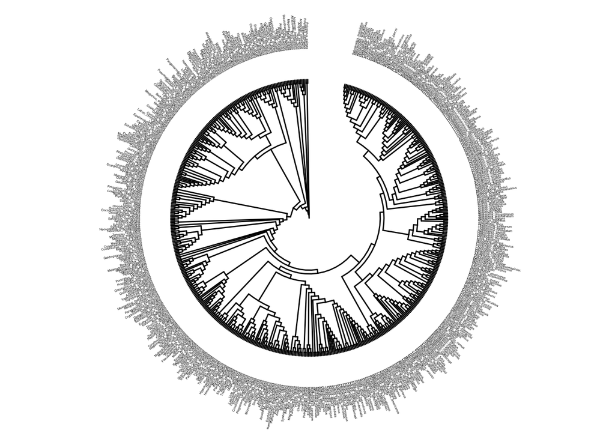

```r
# Identify species to drop
species_to_drop <- setdiff(tree$tip.label, summary_data_act$species_underscored)
# we will drop 80 species (no bony fishes) from the tree

# Prune the tree
tree_act <- drop.tip(tree, species_to_drop)

# Align data and tree
datF <- summary_data_act %>%
  column_to_rownames("species_underscored")

dat_tree <- datF %>%
  filter(row.names(.) %in% tree_act$tip.label)

# Add missing species
missing_species <- setdiff(tree_act$tip.label, row.names(dat_tree))
dat_tree_NA <- data.frame(matrix(NA, nrow = length(missing_species), ncol = ncol(datF)))
row.names(dat_tree_NA) <- missing_species
colnames(dat_tree_NA) <- colnames(datF)
Data <- rbind(dat_tree, dat_tree_NA)
Data <- Data[match(tree_act$tip.label, row.names(Data)), ]

# Plot with species names
circ_names_act <- ggtree(tree_act, layout = "fan", open.angle = 15, branch.length="none") +
  geom_tiplab(offset = 8, hjust = 0, size = 0.9)
circ_names_act <- rotate_tree(circ_names_act, 90)
circ_names_act
```

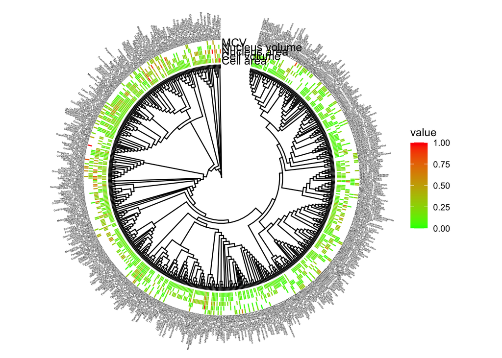

```r
# Create a new plot with heatmap for each trait using a single scale
tree_data_act <- gheatmap(
  circ_names_act,
  Data,
  width = 0.2,
  offset = 0,
  colnames_offset_x = 0,
  colnames_offset_y = 0,
  font.size = 4,
  hjust = 0
)
tree_data_act
```

```r
# Apply the same scale for all traits
tree_data_act <- tree_data_act +
  scale_fill_viridis_c(option = "H", name = "Normalised Cell Traits", na.value = "grey90") +
  theme(
    legend.position = c(0.59, 0.55),
    legend.title.position = "top",
    legend.title.align = 0.5,
    legend.direction = "horizontal",
    legend.key = element_blank(),
    legend.background=element_blank(),
    legend.key.width = unit(0.9, "cm"),
    legend.key.height = unit(0.7, "cm")
  )

# ------------------------------------------------------------------------------
```

## Figure non-Actinopterygii

```r
summary_data_no_act <- dat %>%
  filter(class != "Actinopterygii") %>%
  group_by(species_underscored) %>%
  summarise(across(c(cell_area, cell_volume, nucleus_area, nucleus_volume, mcv),
                   ~ mean(., na.rm = TRUE)),
            .groups = "drop")%>%
  rename(
    "Cell area" = cell_area,
    "Cell volume" = cell_volume,
    "Nucleus area" = nucleus_area,
    "Nucleus volume" = nucleus_volume,
    "MCV" = mcv
  )

summary_data_no_act <- summary_data_no_act %>%
  mutate(across(c("Cell area", "Cell volume", "Nucleus area", "Nucleus volume", "MCV"),
                ~ (.-min(., na.rm = TRUE)) / (max(., na.rm = TRUE) - min(., na.rm = TRUE))))  # scale min-max by variable
summary_data_no_act
```

```
## # A tibble: 65 × 6
##    species_underscored `Cell area` `Cell volume` `Nucleus area` `Nucleus volume`
##    <chr>                     <dbl>         <dbl>          <dbl>            <dbl>
##  1 Aetobatus_narinari       0.133        0.0759        NaN              NaN
##  2 Aptychotrema_rostr…      0.153      NaN               0.185          NaN
##  3 Bathyraja_parmifera      0.140      NaN               0.327          NaN
##  4 Bathytoshia_centro…      0.145        0.0845          0.217            0.249
##  5 Carcharhinus_brach…      0.0800     NaN               0.135          NaN
##  6 Carcharhinus_falci…      0.0762       0.0390        NaN              NaN
##  7 Carcharhinus_leucas      0.0790       0.0404        NaN              NaN
##  8 Carcharhinus_macul…      0.0178       0.00194         0.0498           0.0335
##  9 Carcharhinus_melan…      0.0424     NaN               0.103          NaN
## 10 Carcharhinus_milbe…      0.114        0.0794        NaN              NaN
## # ℹ 55 more rows
## # ℹ 1 more variable: MCV <dbl>
```

```r
unique(summary_data_no_act$species_underscored)
```

```
##  [1] "Aetobatus_narinari"         "Aptychotrema_rostrata"
##  [3] "Bathyraja_parmifera"        "Bathytoshia_centroura"
##  [5] "Carcharhinus_brachyurus"    "Carcharhinus_falciformis"
##  [7] "Carcharhinus_leucas"        "Carcharhinus_maculipinnis"
##  [9] "Carcharhinus_melanopterus"  "Carcharhinus_milberti"
## [11] "Carcharhinus_obscurus"      "Carcharhinus_plumbeus"
## [13] "Centroscymnus_coelolepis"   "Centroscymnus_crepidater"
## [15] "Centroscymnus_owstoni"      "Chiloscyllium_punctatum"
## [17] "Dipturus_batis"             "Dipturus_chilensis"
## [19] "Dipturus_laevis"            "Etmopterus_brachyurus"
## [21] "Etmopterus_granulosus"      "Fluvitrygon_signifer"
## [23] "Galeocerdo_cuvier"          "Geotria_australis"
## [25] "Ginglymostoma_cirratum"     "Hemiscyllium_ocellatum"
## [27] "Hemitrygon_bennettii"       "Heterodontus_francisci"
## [29] "Hypanus_americanus"         "Isurus_oxyrinchus"
```

[output cut: 18 more lines]

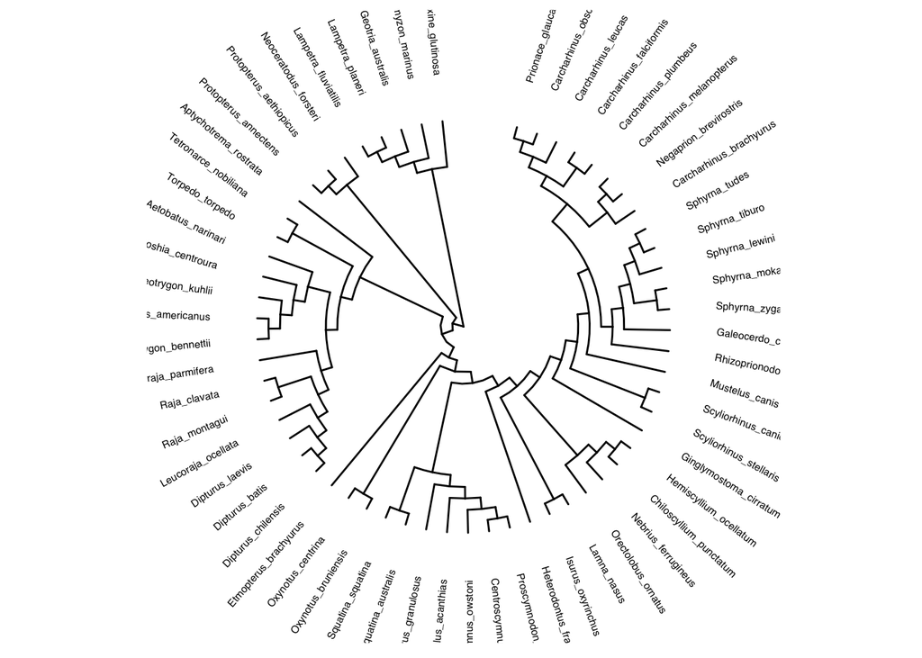

```r
# Identify species to drop
species_to_drop <- setdiff(tree$tip.label, summary_data_no_act$species_underscored)

# Prune the tree
tree_no_act <- drop.tip(tree, species_to_drop)

# Align data and tree
datF <- summary_data_no_act %>%
  column_to_rownames("species_underscored")

dat_tree <- datF %>%
  filter(row.names(.) %in% tree_no_act$tip.label)

# Add missing species
missing_species <- setdiff(tree_no_act$tip.label, row.names(dat_tree))
dat_tree_NA <- data.frame(matrix(NA, nrow = length(missing_species), ncol = ncol(datF)))
row.names(dat_tree_NA) <- missing_species
colnames(dat_tree_NA) <- colnames(datF)
Data <- rbind(dat_tree, dat_tree_NA)
Data <- Data[match(tree_no_act$tip.label, row.names(Data)), ]

# Plot with species names
circ_names_no_act <- ggtree(tree_no_act, layout = "fan", open.angle = 15, branch.length="none") +
  geom_tiplab(offset = 4, hjust = 0, size = 2)
circ_names_no_act <- rotate_tree(circ_names_no_act, 90)
circ_names_no_act
```

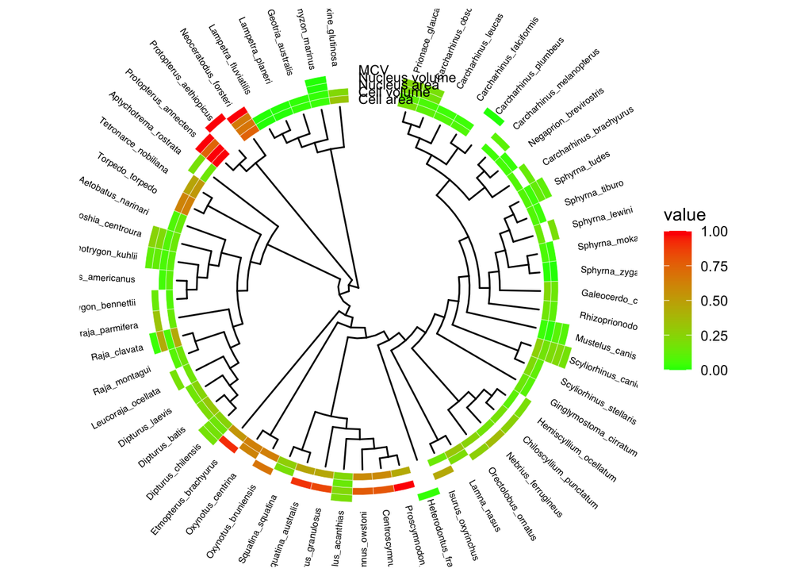

```r
# Create a new plot with heatmap for each trait using a single scale
tree_data_no_act <- gheatmap(
  circ_names_no_act,
  Data,
  width = 0.2,
  offset = 0,
  colnames_offset_x = 0,
  colnames_offset_y = 0,
  font.size = 3,
  hjust = 0
)
tree_data_no_act
```

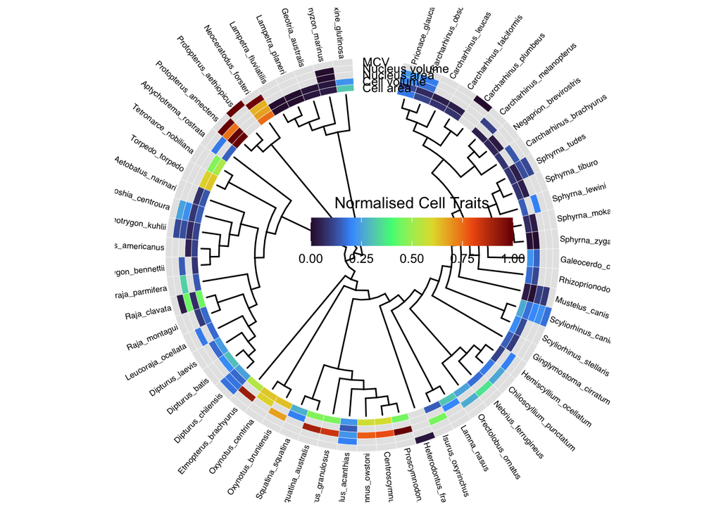

```r
# Apply the same scale for all traits
tree_data_no_act <- tree_data_no_act +
  scale_fill_viridis_c(option = "H",
                       name = "Normalised Cell Traits",
                       na.value = "grey90") +
  theme(
    legend.position = c(0.6, 0.55),
    legend.title.position = "top",
    legend.title.align = 0.5,
    legend.direction = "horizontal",
    legend.key = element_blank(),
    legend.background=element_blank(),
    legend.key.width = unit(1, "cm"),
    legend.key.height = unit(0.7, "cm")
  )

tree_data_no_act
```

## Add taxonomy based on FishBase

```r
# Extract the list of species names reported in the original dataset
species_list <- dat$species_reported

# Validate the species names using FishBase to ensure accuracy
validated_species <- validate_names(species_list)

# Load the complete taxonomy backbone from FishBase
taxonomy_data <- load_taxa()

# Filter the taxonomy data to retain only the species that were validated
# Select key taxonomic ranks: Class, Order, Family, Genus, and Species
# Rename each selected column by appending 'fish_base' to indicate the source is FishBase
taxonomy_fb <- taxonomy_data %>%
  filter(Species %in% validated_species) %>%
  select(Class, Order, Family, Genus, Species) %>%
  rename_with(~ tolower(.x)) %>%
  rename_with(~ paste0(.x, "_fish_base"))

# Join the FishBase taxonomy information back to the original dataset
dat <- dat %>%
  left_join(taxonomy_fb, by = c("species_reported" = "species_fish_base"))

# A quick inspection of the information extracted from FishBase reveals that many # species names are not contained in FishBase, resulting in NA values for the backbone taxonomy for several species.
```

# Export the ErythroCite Database

```r
# check names y sselec the most relevamt columns
names(dat)
```

```
##  [1] "species_reported"     "double_checked"       "database"
##  [4] "key"                  "body_mass_gram"       "sex"
##  [7] "life_stage"           "lat_dec"              "long_dec"
## [10] "location_description" "sample_size"          "number_of_specimens"
## [13] "estimate_error_type"  "cell_length"          "cell_length_error"
## [16] "cell_width"           "cell_width_error"     "cell_area"
## [19] "cell_area_error"      "cell_volume"          "cell_volume_error"
## [22] "mcv"                  "mcv_error"            "nucleus_length"
## [25] "nucleus_length_error" "nucleus_width"        "nucleus_width_error"
## [28] "nucleus_area"         "nucleus_area_error"   "nucleus_volume"
## [31] "nucleus_volume_error" "notes"                "phylum"
## [34] "class"                "order"                "family"
## [37] "genus"                "species"              "source"
## [40] "taxo_level"           "isMarine"             "isBrackish"
## [43] "isFresh"              "realm"                "species_underscored"
## [46] "cell_length_sd"       "cell_width_sd"        "cell_area_sd"
## [49] "cell_volume_sd"       "mcv_sd"               "nucleus_length_sd"
## [52] "nucleus_width_sd"     "nucleus_area_sd"      "nucleus_volume_sd"
## [55] "address"              "country_collection"   "subcontinent"
## [58] "class_fish_base"      "order_fish_base"      "family_fish_base"
## [61] "genus_fish_base"
```

```r
# slect the most releventa columns and sort where is needed
ErythroCite_DB_v1.0.0 <- dat %>%
  select(key, phylum, class, order, family, genus, species, species_reported, species_underscored,
         class_fish_base, order_fish_base, family_fish_base, genus_fish_base,
         database,
         location_description, lat_dec, long_dec, country_collection, subcontinent, realm,
         body_mass_gram, sex, life_stage, number_of_specimens,
         cell_length, cell_width, cell_area, cell_volume, mcv,
         nucleus_length, nucleus_width, nucleus_area, nucleus_volume,
         cell_length_sd, cell_width_sd, cell_area_sd, cell_volume_sd, mcv_sd,
         nucleus_length_sd, nucleus_width_sd, nucleus_area_sd, nucleus_volume_sd, notes)

names(ErythroCite_DB_v1.0.0)
```

```
##  [1] "key"                  "phylum"               "class"
##  [4] "order"                "family"               "genus"
##  [7] "species"              "species_reported"     "species_underscored"
## [10] "class_fish_base"      "order_fish_base"      "family_fish_base"
## [13] "genus_fish_base"      "database"             "location_description"
## [16] "lat_dec"              "long_dec"             "country_collection"
## [19] "subcontinent"         "realm"                "body_mass_gram"
## [22] "sex"                  "life_stage"           "number_of_specimens"
## [25] "cell_length"          "cell_width"           "cell_area"
## [28] "cell_volume"          "mcv"                  "nucleus_length"
## [31] "nucleus_width"        "nucleus_area"         "nucleus_volume"
## [34] "cell_length_sd"       "cell_width_sd"        "cell_area_sd"
## [37] "cell_volume_sd"       "mcv_sd"               "nucleus_length_sd"
## [40] "nucleus_width_sd"     "nucleus_area_sd"      "nucleus_volume_sd"
## [43] "notes"
```

```r
# export file as csv and excel
write.csv(ErythroCite_DB_v1.0.0, "../manuscript/ErythroCite_DB_v1.0.0.csv", row.names = FALSE)

#  and excel
writexl::write_xlsx(ErythroCite_DB_v1.0.0, "../manuscript/ErythroCite_DB_v1.0.0.xlsx")
```

# References

- Pottier, P., Burke, S., Drobniak, S. M., Lagisz, M. & Nakagawa, S. Sexual (in)equality? A meta-analysis of sex differences in thermal acclimation capacity across ectotherms. Functional Ecology **35**, 2663–2678 (2021).
- Benfey, T. J. & Sutterlin, A. M. The haematology of triploid landlocked Atlantic salmon, *Salmo salar* L. Journal of Fish Biology **24**, 333–338 (1984).
- Gregory, T. R. Animal genome size database. http://www.genomesize.com/. (2024).

# Session information

```r
session_info() %>%
  details(summary = 'Current Session Information', open = TRUE)
```

**Current Session Information**

```r
─ Session info ───────────────────────────────────────────────────────────────
 setting  value
 version  R version 4.3.2 (2023-10-31)
 os       macOS 26.2
 system   aarch64, darwin20
 ui       X11
 language (EN)
 collate  en_US.UTF-8
 ctype    en_US.UTF-8
 tz       Europe/Amsterdam
 date     2026-02-09
 pandoc   3.4 @ /Applications/RStudio.app/Contents/Resources/app/quarto/bin/tools/aarch64/ (via rmarkdown)
 quarto   1.6.42 @ /Applications/RStudio.app/Contents/Resources/app/quarto/bin/quarto

─ Packages ───────────────────────────────────────────────────────────────────
 package       * version date (UTC) lib source
 abind           1.4-8   2024-09-12 [1] CRAN (R 4.3.3)
 ape           * 5.8-1   2024-12-16 [1] CRAN (R 4.3.3)
 aplot           0.2.5   2025-02-27 [1] CRAN (R 4.3.3)
 backports       1.5.0   2024-05-23 [1] CRAN (R 4.3.3)
 bibtex          0.5.1   2023-01-26 [1] CRAN (R 4.3.3)
 blob            1.2.4   2023-03-17 [1] CRAN (R 4.3.3)
 bookdown        0.43    2025-04-15 [1] CRAN (R 4.3.3)
 broom           1.0.8   2025-03-28 [1] CRAN (R 4.3.3)
 bslib           0.9.0   2025-01-30 [1] CRAN (R 4.3.3)
 cachem          1.1.0   2024-05-16 [1] CRAN (R 4.3.3)
 car             3.1-3   2024-09-27 [1] CRAN (R 4.3.3)
 carData         3.0-5   2022-01-06 [1] CRAN (R 4.3.3)
 class           7.3-23  2025-01-01 [1] CRAN (R 4.3.3)
 classInt        0.4-11  2025-01-08 [1] CRAN (R 4.3.3)
 cli             3.6.5   2025-04-23 [1] CRAN (R 4.3.3)
 clipr           0.8.0   2022-02-22 [1] CRAN (R 4.3.3)
 codetools       0.2-20  2024-03-31 [1] CRAN (R 4.3.3)
 cowplot       * 1.1.3   2024-01-22 [1] CRAN (R 4.3.1)
 curl            6.2.3   2025-05-24 [1] CRAN (R 4.3.3)
 data.table      1.17.4  2025-05-26 [1] CRAN (R 4.3.3)
 data.tree       1.1.0   2023-11-12 [1] CRAN (R 4.3.3)
 DataExplorer  * 0.8.3   2024-01-24 [1] CRAN (R 4.3.1)
 DBI             1.2.3   2024-06-02 [1] CRAN (R 4.3.3)
 dbplyr          2.5.0   2024-03-19 [1] CRAN (R 4.3.1)
 desc            1.4.3   2023-12-10 [1] CRAN (R 4.3.3)
 details       * 0.4.0   2025-02-09 [1] CRAN (R 4.3.3)
 digest          0.6.37  2024-08-19 [1] CRAN (R 4.3.3)
 dplyr         * 1.1.4   2023-11-17 [1] CRAN (R 4.3.1)
 duckdb          1.3.2   2025-07-09 [1] CRAN (R 4.3.3)
 duckdbfs        0.1.0   2025-04-04 [1] CRAN (R 4.3.3)
 e1071           1.7-16  2024-09-16 [1] CRAN (R 4.3.3)
 evaluate        1.0.4   2025-06-18 [1] CRAN (R 4.3.3)
 farver          2.1.2   2024-05-13 [1] CRAN (R 4.3.3)
 fastmap         1.2.0   2024-05-15 [1] CRAN (R 4.3.3)
 fishualize    * 0.2.3   2022-03-08 [1] CRAN (R 4.3.0)
 Formula         1.2-5   2023-02-24 [1] CRAN (R 4.3.3)
 fs              1.6.6   2025-04-12 [1] CRAN (R 4.3.3)
 generics        0.1.4   2025-05-09 [1] CRAN (R 4.3.3)
 ggfun           0.1.8   2024-12-03 [1] CRAN (R 4.3.3)
 ggplot2       * 3.5.2   2025-04-09 [1] CRAN (R 4.3.3)
 ggplotify       0.1.2   2023-08-09 [1] CRAN (R 4.3.0)
 ggpubr        * 0.6.0   2023-02-10 [1] CRAN (R 4.3.0)
 ggsignif        0.6.4   2022-10-13 [1] CRAN (R 4.3.0)
 ggthemes      * 5.1.0   2024-02-10 [1] CRAN (R 4.3.1)
 ggtree        * 3.10.1  2024-02-27 [1] Bioconductor 3.18 (R 4.3.2)
 glue            1.8.0   2024-09-30 [1] CRAN (R 4.3.3)
 gridExtra       2.3     2017-09-09 [1] CRAN (R 4.3.3)
 gridGraphics    0.5-1   2020-12-13 [1] CRAN (R 4.3.3)
 gtable          0.3.6   2024-10-25 [1] CRAN (R 4.3.3)
 htmltools       0.5.8.1 2024-04-04 [1] CRAN (R 4.3.3)
 htmlwidgets     1.6.4   2023-12-06 [1] CRAN (R 4.3.1)
 httr            1.4.7   2023-08-15 [1] CRAN (R 4.3.0)
 igraph          2.1.4   2025-01-23 [1] CRAN (R 4.3.3)
 jquerylib       0.1.4   2021-04-26 [1] CRAN (R 4.3.3)
 jsonlite        2.0.0   2025-03-27 [1] CRAN (R 4.3.3)
 kableExtra    * 1.4.0   2024-01-24 [1] CRAN (R 4.3.1)
 KernSmooth      2.23-26 2025-01-01 [1] CRAN (R 4.3.3)
 knitr           1.50    2025-03-16 [1] CRAN (R 4.3.3)
 labeling        0.4.3   2023-08-29 [1] CRAN (R 4.3.3)
 lattice         0.22-7  2025-04-02 [1] CRAN (R 4.3.3)
 lazyeval        0.2.2   2019-03-15 [1] CRAN (R 4.3.3)
 lifecycle       1.0.4   2023-11-07 [1] CRAN (R 4.3.3)
 lubridate       1.9.4   2024-12-08 [1] CRAN (R 4.3.3)
 magrittr        2.0.3   2022-03-30 [1] CRAN (R 4.3.3)
 maps            3.4.3   2025-05-26 [1] CRAN (R 4.3.3)
 memoise         2.0.1   2021-11-26 [1] CRAN (R 4.3.3)
 networkD3       0.4.1   2025-04-14 [1] CRAN (R 4.3.3)
 nlme            3.1-168 2025-03-31 [1] CRAN (R 4.3.3)
 patchwork       1.3.0   2024-09-16 [1] CRAN (R 4.3.3)
 pillar          1.10.2  2025-04-05 [1] CRAN (R 4.3.3)
 pkgconfig       2.0.3   2019-09-22 [1] CRAN (R 4.3.3)
 plyr            1.8.9   2023-10-02 [1] CRAN (R 4.3.3)
 png             0.1-8   2022-11-29 [1] CRAN (R 4.3.3)
 proxy           0.4-27  2022-06-09 [1] CRAN (R 4.3.3)
 purrr           1.0.4   2025-02-05 [1] CRAN (R 4.3.3)
 R6              2.6.1   2025-02-15 [1] CRAN (R 4.3.3)
 ragg            1.4.0   2025-04-10 [1] CRAN (R 4.3.3)
 RColorBrewer    1.1-3   2022-04-03 [1] CRAN (R 4.3.3)
 Rcpp            1.1.0   2025-07-02 [1] CRAN (R 4.3.3)
 RefManageR    * 1.4.0   2022-09-30 [1] CRAN (R 4.3.0)
 rfishbase     * 5.0.1   2025-01-12 [1] CRAN (R 4.3.3)
 rlang           1.1.6   2025-04-11 [1] CRAN (R 4.3.3)
 rmarkdown       2.29    2024-11-04 [1] CRAN (R 4.3.3)
 rnaturalearth * 1.0.1   2023-12-15 [1] CRAN (R 4.3.1)
 rstatix         0.7.2   2023-02-01 [1] CRAN (R 4.3.0)
 rstudioapi      0.17.1  2024-10-22 [1] CRAN (R 4.3.3)
 sass            0.4.10  2025-04-11 [1] CRAN (R 4.3.3)
 scales          1.4.0   2025-04-24 [1] CRAN (R 4.3.3)
 sessioninfo   * 1.2.3   2025-02-05 [1] CRAN (R 4.3.3)
 sf              1.0-21  2025-05-15 [1] CRAN (R 4.3.3)
 stringi         1.8.7   2025-03-27 [1] CRAN (R 4.3.3)
 stringr         1.5.1   2023-11-14 [1] CRAN (R 4.3.1)
 svglite         2.2.1   2025-05-12 [1] CRAN (R 4.3.3)
 systemfonts     1.2.3   2025-04-30 [1] CRAN (R 4.3.3)
 terra           1.8-50  2025-05-09 [1] CRAN (R 4.3.3)
 textshaping     1.0.1   2025-05-01 [1] CRAN (R 4.3.3)
 tibble        * 3.2.1   2023-03-20 [1] CRAN (R 4.3.0)
 tidygeocoder  * 1.0.6   2025-03-31 [1] CRAN (R 4.3.3)
 tidyr           1.3.1   2024-01-24 [1] CRAN (R 4.3.1)
 tidyselect      1.2.1   2024-03-11 [1] CRAN (R 4.3.1)
 tidytree        0.4.6   2023-12-12 [1] CRAN (R 4.3.1)
 timechange      0.3.0   2024-01-18 [1] CRAN (R 4.3.3)
 treeio          1.26.0  2023-11-06 [1] Bioconductor
 units           0.8-7   2025-03-11 [1] CRAN (R 4.3.3)
 utf8            1.2.5   2025-05-01 [1] CRAN (R 4.3.3)
 vctrs           0.6.5   2023-12-01 [1] CRAN (R 4.3.3)
 viridisLite     0.4.2   2023-05-02 [1] CRAN (R 4.3.3)
 withr           3.0.2   2024-10-28 [1] CRAN (R 4.3.3)
 writexl         1.5.4   2025-04-15 [1] CRAN (R 4.3.3)
 xfun            0.52    2025-04-02 [1] CRAN (R 4.3.3)
 xml2            1.3.8   2025-03-14 [1] CRAN (R 4.3.3)
 yaml            2.3.10  2024-07-26 [1] CRAN (R 4.3.3)
 yulab.utils     0.2.0   2025-01-29 [1] CRAN (R 4.3.3)

 [1] /Library/Frameworks/R.framework/Versions/4.3-arm64/Resources/library
 * ── Packages attached to the search path.

──────────────────────────────────────────────────────────────────────────────
```